# Análise Exploratória de Dados de Partidos e Eleições (2022-2024)

Ryan Almeida

30/09/2026

# Distribuição dos votos de vereador e presença de outliers

```
## # A tibble: 30 × 7
##    mesorregiao             espectro         n_obs n_partidos n_municipios
##    <fct>                   <fct>            <int>      <int>        <int>
##  1 São Francisco           Extrema esquerda     4          1            4
##  2 Sertão                  Extrema esquerda     5          1            5
##  3 Agreste                 Extrema esquerda     8          1            8
##  4 Mata                    Extrema esquerda    10          1           10
##  5 Metropolitana de Recife Extrema esquerda    12          3           10
##  6 São Francisco           Extrema direita     16          3            9
##  7 São Francisco           Direita             18          6           12
##  8 São Francisco           Esquerda            19          3           12
##  9 São Francisco           Centro-direita      22          5           11
## 10 São Francisco           Centro-esquerda     25          4           14
## 11 Metropolitana de Recife Esquerda            28          3           13
## 12 Sertão                  Extrema direita     34          4           23
```

[output cut: 50 more lines]

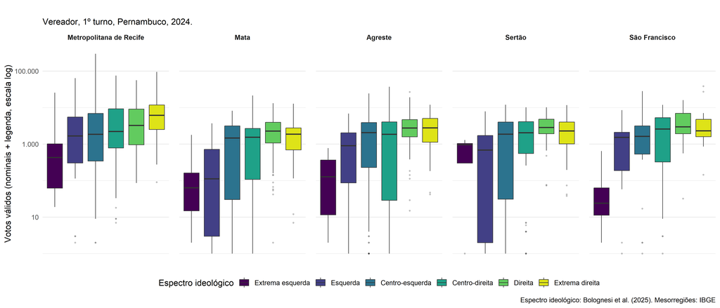

Figura 1. Município × partido, votos absolutos (escala log).

```
## # A tibble: 1 × 2
##       n    nn
##   <int> <int>
## 1     6   184
```

```
## # A tibble: 5 × 8
##   mesorregiao              chi2    gl        p     W     n p_txt     rotulo
##   <fct>                   <dbl> <dbl>    <dbl> <dbl> <int> <chr>     <chr>
## 1 Metropolitana de Recife  47.4     5 4.65e- 9 0.678    14 p < 0,001 "Friedman …
## 2 Mata                    115.      5 4.12e-23 0.534    43 p < 0,001 "Friedman …
## 3 Agreste                 134.      5 4.03e-27 0.376    71 p < 0,001 "Friedman …
## 4 Sertão                   54.2     5 1.89e-10 0.264    41 p < 0,001 "Friedman …
## 5 São Francisco            23.2     5 3.09e- 4 0.309    15 p < 0,001 "Friedman …
```

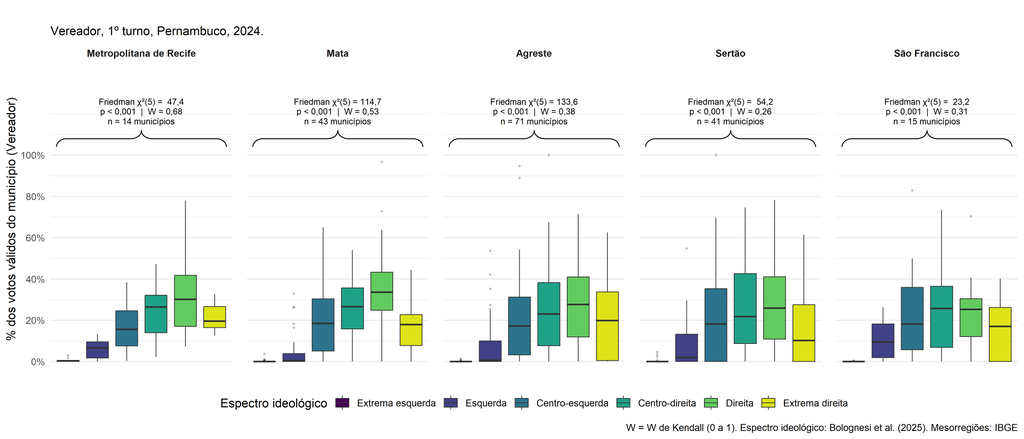

Figura 2. Município × espectro, % dos votos válidos.

Para cada mesorregião, aplicou-se o teste de Friedman, que compara os *postos* da fatia de votos entre os seis campos ideológicos, tratando cada município como um bloco (medidas repetidas). A hipótese nula é $H_0$: os seis campos têm a mesma distribuição de $\%$ de votos. O tamanho de efeito é o $W$ de Kendall, que varia de $0$ a $1$ e mede a concordância entre os municípios na ordenação dos campos.

1. **Os campos ideológicos não têm a mesma fatia de votos.** Em todas as mesorregiões rejeita-se $H_0$ ($p < 0{,}001$). O padrão visível nos gráficos é que os partidos de extrema esquerda ficam próximos de $0\%$ dos votos válidos, enquanto os campos de centro-direita e direita concentram as maiores fatias.
2. **A regularidade desse padrão varia por região.** O $W$ é mais alto na região metropolitana e na Mata e mais baixo no Agreste, no Sertão e em São Francisco. Ou seja, no litoral os municípios ordenam os campos de forma parecida, e no interior a ordem muda mais de município para município. Convém conferir essa descrição com os valores acima.
3. **Comparar o gráfico enganoso com o mais honesto muda a leitura.** Na versão município $\times$ partido, com votos absolutos, o tamanho do município e a mistura de partidos grandes e nanicos dominam a dispersão, e várias caixas repousam sobre $n$ entre $4$ e $12$ observações. Ao usar a fatia de votos do município por campo ideológico, incluindo os zeros, cada caixa passa a ter o mesmo $n$ dentro da região, e a diferença entre os campos aparece sem o efeito do porte.

Limitações

- **Os campos não são independentes.** Em cada município os percentuais somam $100\%$; se um campo sobe, outro necessariamente cai. Isso favorece diferenças “significativas” por construção.
- **O que a variável mede.** É a fatia de votos válidos para vereador em partidos classificados por especialistas, e não a ideologia dos eleitores. O voto para vereador é muito centrado no candidato, então a fatia de um campo não implica adesão programática ao partido.

# Partidos mais votados em Pernambuco (2024)

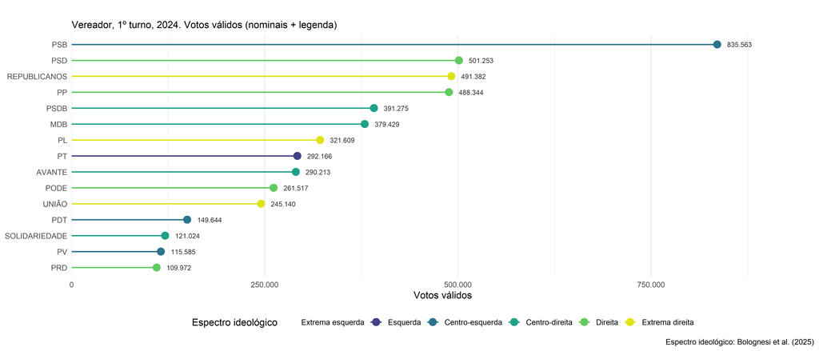

# Prefeitos eleitos em 2024 em seu espectro ideológico

[interactive chart not shown]